# Thomas Analysis

# Re-Organising Data Colums, experimental sites

Zero level, experimental site

```r
  ch40 <- gather(ch4, "olevel", "flux", Tree1h0:Tree12h0, factor_key=TRUE)
ch40
```

```
##        Sampled Tree2h80 Tree3h80 Tree4h80 Tree6h80 Tree8h80 Tree9h80
## 1   2017-07-18    5.547    0.000    0.000    3.457    1.060       NA
## 2   2017-07-20    4.745    0.286    3.305    0.820    0.000    0.000
## 3   2017-07-24    3.474    0.954    2.870    0.213    0.000    0.196
## 4   2017-07-26    6.267    5.035    1.673    2.968    0.000    0.000
## 5   2017-07-27    1.343    0.000    2.031    0.000    0.435    0.267
## 6   2017-07-31    1.266    0.471    1.628    0.000    0.000    0.868
## 7   2017-08-02    1.037   14.127    0.744    0.000    0.000    1.282
## 8   2017-08-03    1.001    0.489    1.573    0.733    1.714    0.000
## 9   2017-08-07    1.646    0.677    2.780    0.000    1.588    0.000
## 10  2017-08-09    4.209    0.050    0.937    0.000    0.355    0.779
## 11  2017-08-10       NA       NA       NA    0.000    0.000    0.000
## 12  2017-08-14   15.210    9.678   19.372    6.221    0.000    0.000
## 13  2017-08-16   17.511   10.488   24.194    0.000    1.847    0.219
## 14  2017-08-18    0.000   12.250   32.987    6.000    0.302    1.535
```

[output cut: 744 more lines]

80cm Level, experimental site

```r
  ch480 <- gather(ch4, "80level", "flux", Tree2h80:Tree12h80, factor_key=TRUE)
```

```r
ch480
```

```
##        Sampled Tree1h0  Tree2h0 Tree3h0 Tree4h0 Tree5h0 Tree6h0 Tree7h0
## 1   2017-07-18      NA   21.921   0.789   9.060      NA   3.347      NA
## 2   2017-07-20   3.440   23.957   2.422   9.660   0.953   3.097   5.405
## 3   2017-07-24   2.858   11.620   0.287  10.763   0.000   1.793   5.722
## 4   2017-07-26   0.000    7.405   0.000   0.857   0.000   1.056   4.758
## 5   2017-07-27   0.000    4.380   3.769   6.070   0.277   1.073   4.234
## 6   2017-07-31   0.634    3.298   0.292   5.474   0.000   0.000   0.181
## 7   2017-08-02   0.591    2.845   0.256   4.568   0.000   0.000   1.778
## 8   2017-08-03   0.490    2.803   0.000   4.408   0.098   0.914   1.517
## 9   2017-08-07   0.000    8.444   1.189   5.625   0.586   0.110   2.185
## 10  2017-08-09   1.066   30.135   0.727   7.208   0.804   2.098   6.290
## 11  2017-08-10      NA       NA      NA      NA      NA   9.166  17.578
## 12  2017-08-14  10.176  129.356  18.530  74.272   3.756  28.784  25.581
## 13  2017-08-16   8.664  130.019  23.080  96.430   5.430  26.432  27.964
## 14  2017-08-18   7.463  152.148   0.000   0.000   1.189  31.544  28.407
```

[output cut: 661 more lines]

170cm Level, experimental site

```r
  ch4170 <- gather(ch4, "170level", "flux", Tree2h170:Tree12h170, factor_key=TRUE)
```

```r
ch4170
```

```
##        Sampled Tree1h0  Tree2h0 Tree3h0 Tree4h0 Tree5h0 Tree6h0 Tree7h0
## 1   2017-07-18      NA   21.921   0.789   9.060      NA   3.347      NA
## 2   2017-07-20   3.440   23.957   2.422   9.660   0.953   3.097   5.405
## 3   2017-07-24   2.858   11.620   0.287  10.763   0.000   1.793   5.722
## 4   2017-07-26   0.000    7.405   0.000   0.857   0.000   1.056   4.758
## 5   2017-07-27   0.000    4.380   3.769   6.070   0.277   1.073   4.234
## 6   2017-07-31   0.634    3.298   0.292   5.474   0.000   0.000   0.181
## 7   2017-08-02   0.591    2.845   0.256   4.568   0.000   0.000   1.778
## 8   2017-08-03   0.490    2.803   0.000   4.408   0.098   0.914   1.517
## 9   2017-08-07   0.000    8.444   1.189   5.625   0.586   0.110   2.185
## 10  2017-08-09   1.066   30.135   0.727   7.208   0.804   2.098   6.290
## 11  2017-08-10      NA       NA      NA      NA      NA   9.166  17.578
## 12  2017-08-14  10.176  129.356  18.530  74.272   3.756  28.784  25.581
## 13  2017-08-16   8.664  130.019  23.080  96.430   5.430  26.432  27.964
## 14  2017-08-18   7.463  152.148   0.000   0.000   1.189  31.544  28.407
```

[output cut: 492 more lines]

# Re-Organising Data Colums, control sites

```r
  ch40c <- gather(ch4, "olevelC", "flux", Tree9h0:Tree11h0, factor_key=TRUE)
```

```r
ch40c
```

```
##       Sampled Tree1h0  Tree2h0 Tree3h0 Tree4h0 Tree5h0 Tree6h0 Tree7h0
## 1  2017-07-18      NA   21.921   0.789   9.060      NA   3.347      NA
## 2  2017-07-20   3.440   23.957   2.422   9.660   0.953   3.097   5.405
## 3  2017-07-24   2.858   11.620   0.287  10.763   0.000   1.793   5.722
## 4  2017-07-26   0.000    7.405   0.000   0.857   0.000   1.056   4.758
## 5  2017-07-27   0.000    4.380   3.769   6.070   0.277   1.073   4.234
## 6  2017-07-31   0.634    3.298   0.292   5.474   0.000   0.000   0.181
## 7  2017-08-02   0.591    2.845   0.256   4.568   0.000   0.000   1.778
## 8  2017-08-03   0.490    2.803   0.000   4.408   0.098   0.914   1.517
## 9  2017-08-07   0.000    8.444   1.189   5.625   0.586   0.110   2.185
## 10 2017-08-09   1.066   30.135   0.727   7.208   0.804   2.098   6.290
## 11 2017-08-10      NA       NA      NA      NA      NA   9.166  17.578
## 12 2017-08-14  10.176  129.356  18.530  74.272   3.756  28.784  25.581
## 13 2017-08-16   8.664  130.019  23.080  96.430   5.430  26.432  27.964
## 14 2017-08-18   7.463  152.148   0.000   0.000   1.189  31.544  28.407
```

[output cut: 241 more lines]

```r
  ch480c <- gather(ch4, "80levelC", "flux", Tree9h80:Tree11h80, factor_key=TRUE)
```

```r
ch480c
```

```
##       Sampled Tree1h0  Tree2h0 Tree3h0 Tree4h0 Tree5h0 Tree6h0 Tree7h0
## 1  2017-07-18      NA   21.921   0.789   9.060      NA   3.347      NA
## 2  2017-07-20   3.440   23.957   2.422   9.660   0.953   3.097   5.405
## 3  2017-07-24   2.858   11.620   0.287  10.763   0.000   1.793   5.722
## 4  2017-07-26   0.000    7.405   0.000   0.857   0.000   1.056   4.758
## 5  2017-07-27   0.000    4.380   3.769   6.070   0.277   1.073   4.234
## 6  2017-07-31   0.634    3.298   0.292   5.474   0.000   0.000   0.181
## 7  2017-08-02   0.591    2.845   0.256   4.568   0.000   0.000   1.778
## 8  2017-08-03   0.490    2.803   0.000   4.408   0.098   0.914   1.517
## 9  2017-08-07   0.000    8.444   1.189   5.625   0.586   0.110   2.185
## 10 2017-08-09   1.066   30.135   0.727   7.208   0.804   2.098   6.290
## 11 2017-08-10      NA       NA      NA      NA      NA   9.166  17.578
## 12 2017-08-14  10.176  129.356  18.530  74.272   3.756  28.784  25.581
## 13 2017-08-16   8.664  130.019  23.080  96.430   5.430  26.432  27.964
## 14 2017-08-18   7.463  152.148   0.000   0.000   1.189  31.544  28.407
```

[output cut: 157 more lines]

```r
  ch4170c <- gather(ch4, "170levelC", "flux", Tree9h170:Tree11h170, factor_key=TRUE)
```

```r
ch4170c
```

```
##       Sampled Tree1h0  Tree2h0 Tree3h0 Tree4h0 Tree5h0 Tree6h0 Tree7h0
## 1  2017-07-18      NA   21.921   0.789   9.060      NA   3.347      NA
## 2  2017-07-20   3.440   23.957   2.422   9.660   0.953   3.097   5.405
## 3  2017-07-24   2.858   11.620   0.287  10.763   0.000   1.793   5.722
## 4  2017-07-26   0.000    7.405   0.000   0.857   0.000   1.056   4.758
## 5  2017-07-27   0.000    4.380   3.769   6.070   0.277   1.073   4.234
## 6  2017-07-31   0.634    3.298   0.292   5.474   0.000   0.000   0.181
## 7  2017-08-02   0.591    2.845   0.256   4.568   0.000   0.000   1.778
## 8  2017-08-03   0.490    2.803   0.000   4.408   0.098   0.914   1.517
## 9  2017-08-07   0.000    8.444   1.189   5.625   0.586   0.110   2.185
## 10 2017-08-09   1.066   30.135   0.727   7.208   0.804   2.098   6.290
## 11 2017-08-10      NA       NA      NA      NA      NA   9.166  17.578
## 12 2017-08-14  10.176  129.356  18.530  74.272   3.756  28.784  25.581
## 13 2017-08-16   8.664  130.019  23.080  96.430   5.430  26.432  27.964
## 14 2017-08-18   7.463  152.148   0.000   0.000   1.189  31.544  28.407
```

[output cut: 157 more lines]

# CH4 Boxplots from Experimental Site, no control spots, Level 0/80/170 cm

```r
  ch1 <- ggplot(ch40,
              aes(x=Sampled,
                  y=flux))
  ch1 <- ch1 +
        geom_boxplot(fill="blue", alpha=0.2) +
          ggtitle("CH4, Level 0cm") +
          labs(x="Sampling Dates", y="CH4 flux") +
          theme(plot.title = element_text(family = "Trebuchet MS", color="#666666", face="bold", size=18, hjust=0)) +
          theme(axis.text.x = element_text(angle = 45, hjust = 1)) +
          scale_y_continuous(name="flux in myg/m-2 h-1", limits=c(0, 20))
```

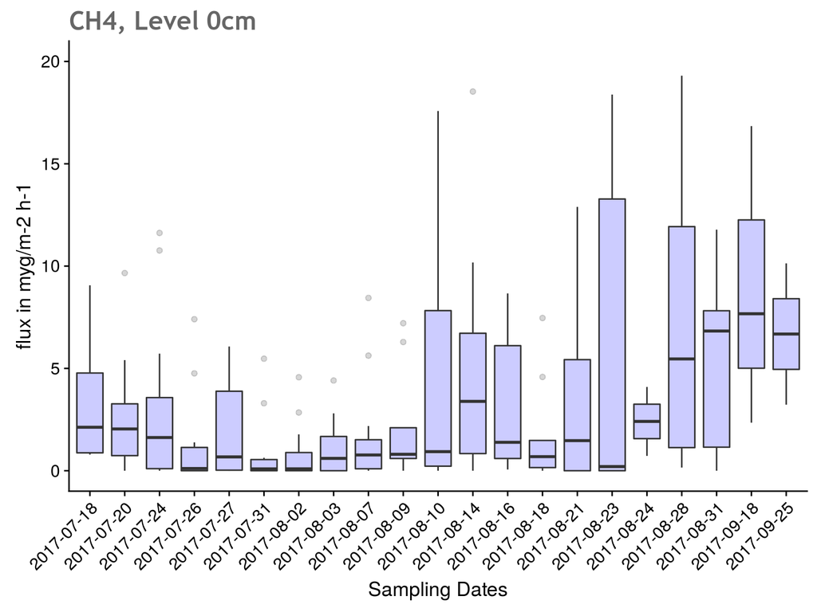

```r
ch1
```

```r
  ch2 <- ggplot(ch480,
              aes(x=Sampled,
                  y=flux))
  ch2 <- ch2 +
        geom_boxplot(fill="blue", alpha=0.2) +
          ggtitle("CH4, Level 80cm") +
          labs(x="Sampling Dates", y="CH4 flux") +
          theme(plot.title = element_text(family = "Trebuchet MS", color="#666666", face="bold", size=18, hjust=0)) +
          theme(axis.text.x = element_text(angle = 45, hjust = 1)) +
          scale_y_continuous(name="flux in myg/m-2 h-1", limits=c(0, 20))
```

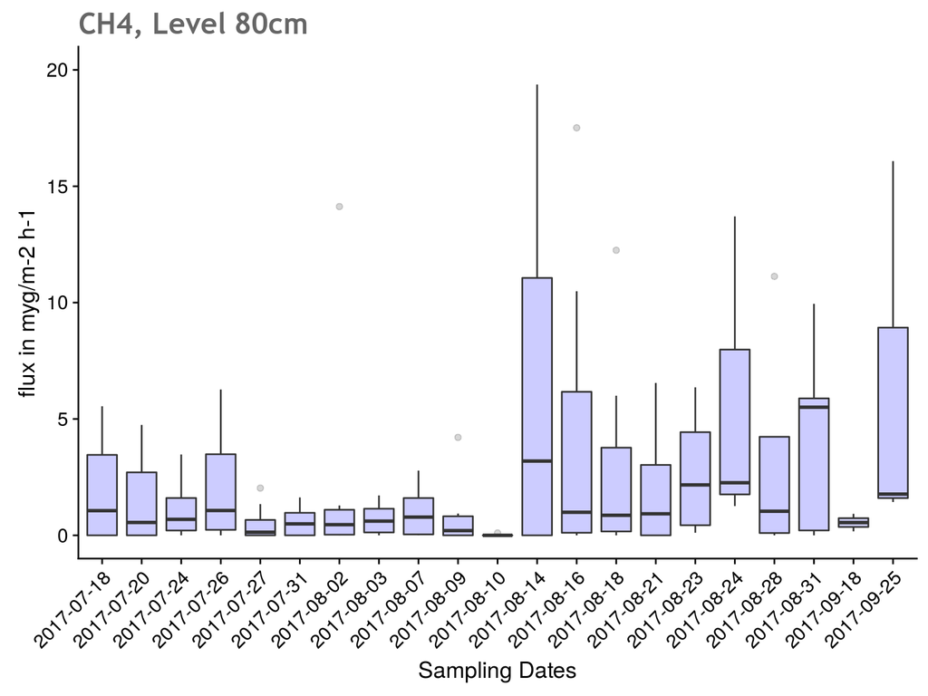

```r
  ch2
```

```r
  ch3 <- ggplot(ch4170,
              aes(x=Sampled,
                  y=flux))
  ch3 <- ch3 +
        geom_boxplot(fill="blue", alpha=0.2) +
          ggtitle("CH4, Level 180cm") +
          labs(x="Sampling Dates", y="CH4 flux") +
          theme(plot.title = element_text(family = "Trebuchet MS", color="#666666", face="bold", size=18, hjust=0)) +
          theme(axis.text.x = element_text(angle = 45, hjust = 1)) +
          scale_y_continuous(name="flux in myg/m-2 h-1", limits=c(0, 20))
```

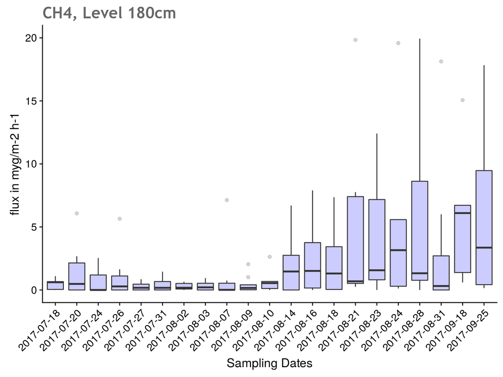

```r
  ch3
```

# CH4 Boxplots from Control Site, no control spots, Level 0/80/170 cm

```r
  chc1 <- ggplot(ch40c,
              aes(x=Sampled,
                  y=flux))
  chc1 <- chc1 +
        geom_boxplot(fill="blue", alpha=0.2) +
          ggtitle("Control site: CH4, Level 0cm") +
          labs(x="Sampling Dates", y="CH4 flux") +
          theme(plot.title = element_text(family = "Trebuchet MS", color="#666666", face="bold", size=18, hjust=0)) +
          theme(axis.text.x = element_text(angle = 45, hjust = 1)) +
          scale_y_continuous(name="flux in myg/m-2 h-1", limits=c(0, 20))
```

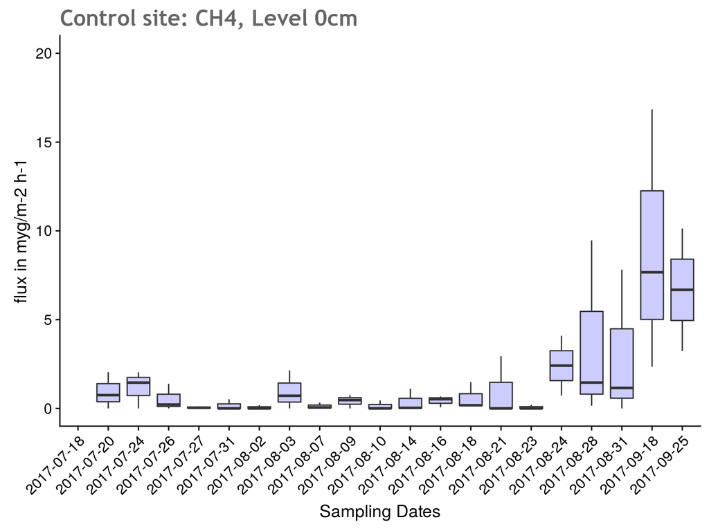

```r
  chc1
```

```r
  chc2 <- ggplot(ch480c,
              aes(x=Sampled,
                  y=flux))
  chc2 <- chc2 +
        geom_boxplot(fill="blue", alpha=0.2) +
          ggtitle("Control site: CH4, Level 80cm") +
          labs(x="Sampling Dates", y="CH4 flux") +
          theme(plot.title = element_text(family = "Trebuchet MS", color="#666666", face="bold", size=18, hjust=0)) +
          theme(axis.text.x = element_text(angle = 45, hjust = 1)) +
          scale_y_continuous(name="flux in myg/m-2 h-1", limits=c(0, 5))
```

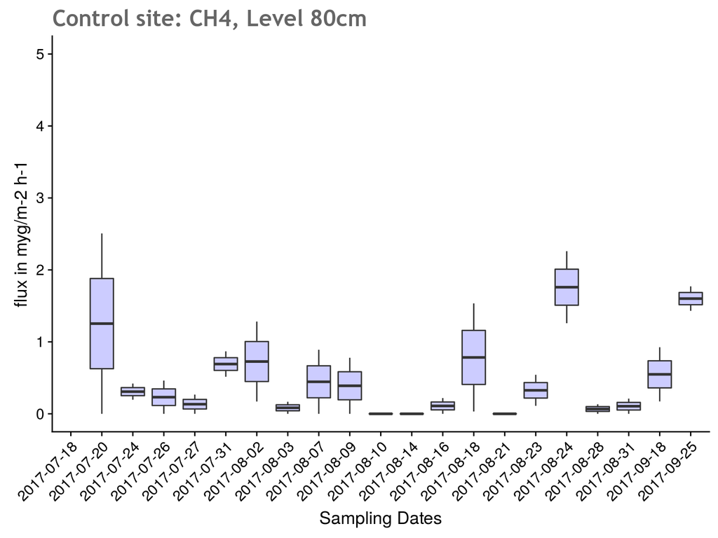

```r
chc2
```

```r
  chc3 <- ggplot(ch4170c,
              aes(x=Sampled,
                  y=flux))
  chc3 <- chc3 +
        geom_boxplot(fill="blue", alpha=0.2) +
          ggtitle("Control site: CH4, Level 180cm") +
          labs(x="Sampling Dates", y="CH4 flux") +
          theme(plot.title = element_text(family = "Trebuchet MS", color="#666666", face="bold", size=18, hjust=0)) +
          theme(axis.text.x = element_text(angle = 45, hjust = 1)) +
          scale_y_continuous(name="flux in myg/m-2 h-1", limits=c(0, 10))
```

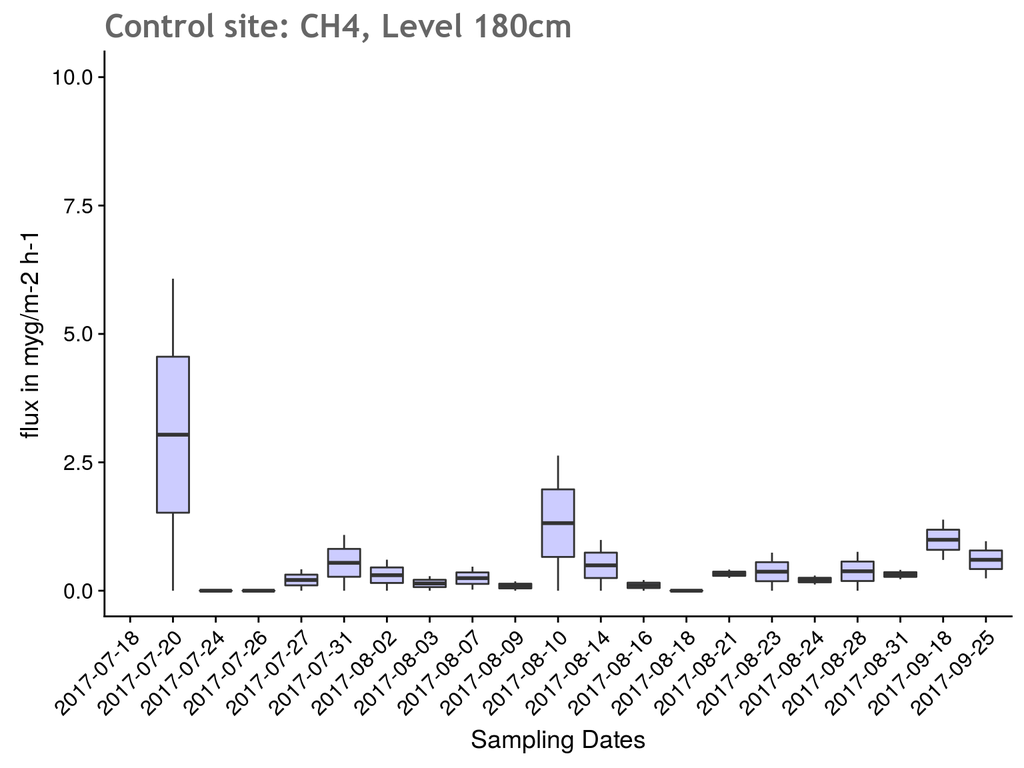

```r
  chc3
```

# Extra Tests with CO2

# Data Import,

Select my file and read data into ‘dat’ dataframe File contains CO2 fluxes for the SummerSchool irrigation experiment only. For extended time slots, another file (see below) will be used.

```r
co2<- read.csv("co2R.csv", header = TRUE)
```

```r
co2
```

```
##       Sampled Tree1h0 Tree2h0 Tree3h0 Tree4h0 Tree5h0 Tree6h0 Tree7h0
## 1  2017-07-05  0.2895  0.5233  0.3022  1.0331  0.6303  0.4593  0.6619
## 2  2017-07-20  0.2695  0.9320  0.5308  0.5887  0.6484  0.8975  0.3364
## 3  2017-07-24  0.1939  1.0004  0.9459  0.6686  0.8650  0.8244  0.6562
## 4  2017-07-26  0.2385  1.2529  1.0461  1.0122  0.8334  1.1031  0.6878
## 5  2017-07-27  0.1599  1.1260  0.8538  0.9659  0.8844  0.4928  0.6364
## 6  2017-07-28  0.8107  1.0054  0.5988  1.1580      NA      NA      NA
## 7  2017-07-31  0.2201  1.0697  0.4885  1.2030  0.8086  0.5421  0.5271
## 8  2017-08-02  0.4255  0.9308  0.6493  0.6047  0.6875  0.7133  0.7671
## 9  2017-08-03  0.1240  0.8778  0.4617  0.6873  0.6785  0.7893  0.4016
## 10 2017-08-07  0.2618  0.7319  0.4699  0.9337  0.5661  0.7371  0.3856
## 11 2017-08-09  0.2115  0.7221  0.6267  0.9495  0.6427  0.6223  0.5070
## 12 2017-08-09  0.2115  0.7221  0.6267  0.9495  0.6427  0.6223  0.5070
## 13 2017-08-10  0.1358  0.8270  0.8981  0.7111  0.8354  1.0882  0.5977
## 14 2017-08-14  0.1905  0.7683  0.5554  1.1376  0.5989  0.6266  0.6656
```

[output cut: 113 more lines]

# Check Table View

```r
  head(co2)
```

```
##      Sampled Tree1h0 Tree2h0 Tree3h0 Tree4h0 Tree5h0 Tree6h0 Tree7h0
## 1 2017-07-05  0.2895  0.5233  0.3022  1.0331  0.6303  0.4593  0.6619
## 2 2017-07-20  0.2695  0.9320  0.5308  0.5887  0.6484  0.8975  0.3364
## 3 2017-07-24  0.1939  1.0004  0.9459  0.6686  0.8650  0.8244  0.6562
## 4 2017-07-26  0.2385  1.2529  1.0461  1.0122  0.8334  1.1031  0.6878
## 5 2017-07-27  0.1599  1.1260  0.8538  0.9659  0.8844  0.4928  0.6364
## 6 2017-07-28  0.8107  1.0054  0.5988  1.1580      NA      NA      NA
##   Tree8h0 Tree12h0 Tree2h80 Tree3h80 Tree4h80 Tree6h80 Tree8h80 Tree12h80
## 1  0.6840       NA   0.2464   0.5427   0.6433   0.4083   0.6648        NA
## 2  0.7497   0.4781   0.3635   0.6343   0.5619   0.3778   0.5704    0.4260
## 3  0.9568   0.3115   0.5164   0.9841   0.9635   0.4824   0.6426    0.3914
## 4  1.3786   0.6314   0.7164   0.8799   0.8675   0.4347   1.2502    0.3813
## 5  1.2658   0.3340   0.4460   0.6995   0.8586   0.4165   0.5643    0.4121
## 6      NA       NA   0.6703   1.3755   1.6667       NA       NA        NA
##   Tree2h170 Tree3h170 Tree4h170 Tree6h170 Tree8h170 Tree12h170 Tree9h0
## 1    0.1872    0.5475    0.5173    0.6703    0.5433         NA  0.4805
## 2    0.4955    0.5233    0.6141    0.2824    0.4549     0.5012  0.2444
## 3    0.4641    0.7055    0.6831    0.4477    0.5600     0.3511  0.3975
## 4    0.6228    0.8551    0.7614    0.8118    1.4201         NA  0.3403
## 5    1.0344    0.8504    0.8223    1.0648    0.7501     0.6356  0.2568
## 6    2.0620    0.9538    0.5415        NA        NA         NA      NA
##   Tree10h0 Tree11h0 Tree9h80 Tree11h80 Tree9h170 Tree11h170 TSYS TAIR
## 1   1.6494   0.3350   0.2534    0.9470    0.4662     0.5640   25   NA
## 2   0.7636   0.4754   0.2398    0.4190    0.2772     0.3025   25   NA
## 3   1.1615   0.4653   0.2811    0.3970    0.3247     0.2872   25   NA
## 4   0.7398   0.3445   0.3189    0.4248    0.5255     0.3859   25   NA
## 5   0.8783   0.2625   0.3818    0.4599    0.5783     0.4938   25   NA
## 6       NA       NA       NA        NA        NA         NA   25   NA
```

# Data are still in wrong format (wide instead of long)

Thus, original data table needs to be converted /gathered - library ‘tidyr’ to be added to library list at the beginning

The arguments to gather(): - data: Data object - key: Name of new key column (made from names of data columns) - value: Name of new value column - …: Names of source columns that contain values - factor_key: Treat the new key column as a factor (instead of character vector)

# Re-Organising Data Colums, experimental sites

Zero level, experimental site

```r
  co20 <- gather(co2, "olevel", "flux", Tree1h0:Tree12h0, factor_key=TRUE)
co20
```

```
##        Sampled Tree2h80 Tree3h80 Tree4h80 Tree6h80 Tree8h80 Tree12h80
## 1   2017-07-05   0.2464   0.5427   0.6433   0.4083   0.6648        NA
## 2   2017-07-20   0.3635   0.6343   0.5619   0.3778   0.5704    0.4260
## 3   2017-07-24   0.5164   0.9841   0.9635   0.4824   0.6426    0.3914
## 4   2017-07-26   0.7164   0.8799   0.8675   0.4347   1.2502    0.3813
## 5   2017-07-27   0.4460   0.6995   0.8586   0.4165   0.5643    0.4121
## 6   2017-07-28   0.6703   1.3755   1.6667       NA       NA        NA
## 7   2017-07-31   0.6677   1.7595   0.6729   0.4257   0.7142    0.3518
## 8   2017-08-02   0.5094   0.6987   0.5923   0.3832   0.6076    0.4780
## 9   2017-08-03   0.4366   0.6514   0.6581   0.3015   0.6322    0.3705
## 10  2017-08-07   0.3042   0.5974   0.6915   0.3641   0.4420    0.2361
## 11  2017-08-09   0.4622   0.6773   0.7914   0.3133   0.6872    0.2863
## 12  2017-08-09   0.4622   0.6773   0.7914   0.3133   0.6872    0.2863
## 13  2017-08-10   0.3978   0.5645   0.5500   0.4647   0.5459    0.5997
## 14  2017-08-14   0.3977   0.6455   0.8260   0.3939   0.3927    0.1460
```

[output cut: 1105 more lines]

80cm Level, experimental site

```r
  co280 <- gather(co2, "80level", "flux", Tree2h80:Tree12h80, factor_key=TRUE)
```

```r
co280
```

```
##        Sampled Tree1h0 Tree2h0 Tree3h0 Tree4h0 Tree5h0 Tree6h0 Tree7h0
## 1   2017-07-05  0.2895  0.5233  0.3022  1.0331  0.6303  0.4593  0.6619
## 2   2017-07-20  0.2695  0.9320  0.5308  0.5887  0.6484  0.8975  0.3364
## 3   2017-07-24  0.1939  1.0004  0.9459  0.6686  0.8650  0.8244  0.6562
## 4   2017-07-26  0.2385  1.2529  1.0461  1.0122  0.8334  1.1031  0.6878
## 5   2017-07-27  0.1599  1.1260  0.8538  0.9659  0.8844  0.4928  0.6364
## 6   2017-07-28  0.8107  1.0054  0.5988  1.1580      NA      NA      NA
## 7   2017-07-31  0.2201  1.0697  0.4885  1.2030  0.8086  0.5421  0.5271
## 8   2017-08-02  0.4255  0.9308  0.6493  0.6047  0.6875  0.7133  0.7671
## 9   2017-08-03  0.1240  0.8778  0.4617  0.6873  0.6785  0.7893  0.4016
## 10  2017-08-07  0.2618  0.7319  0.4699  0.9337  0.5661  0.7371  0.3856
## 11  2017-08-09  0.2115  0.7221  0.6267  0.9495  0.6427  0.6223  0.5070
## 12  2017-08-09  0.2115  0.7221  0.6267  0.9495  0.6427  0.6223  0.5070
## 13  2017-08-10  0.1358  0.8270  0.8981  0.7111  0.8354  1.0882  0.5977
## 14  2017-08-14  0.1905  0.7683  0.5554  1.1376  0.5989  0.6266  0.6656
```

[output cut: 733 more lines]

170cm Level, experimental site

```r
  co2170 <- gather(co2, "170level", "flux", Tree2h170:Tree12h170, factor_key=TRUE)
```

```r
co2170
```

```
##        Sampled Tree1h0 Tree2h0 Tree3h0 Tree4h0 Tree5h0 Tree6h0 Tree7h0
## 1   2017-07-05  0.2895  0.5233  0.3022  1.0331  0.6303  0.4593  0.6619
## 2   2017-07-20  0.2695  0.9320  0.5308  0.5887  0.6484  0.8975  0.3364
## 3   2017-07-24  0.1939  1.0004  0.9459  0.6686  0.8650  0.8244  0.6562
## 4   2017-07-26  0.2385  1.2529  1.0461  1.0122  0.8334  1.1031  0.6878
## 5   2017-07-27  0.1599  1.1260  0.8538  0.9659  0.8844  0.4928  0.6364
## 6   2017-07-28  0.8107  1.0054  0.5988  1.1580      NA      NA      NA
## 7   2017-07-31  0.2201  1.0697  0.4885  1.2030  0.8086  0.5421  0.5271
## 8   2017-08-02  0.4255  0.9308  0.6493  0.6047  0.6875  0.7133  0.7671
## 9   2017-08-03  0.1240  0.8778  0.4617  0.6873  0.6785  0.7893  0.4016
## 10  2017-08-07  0.2618  0.7319  0.4699  0.9337  0.5661  0.7371  0.3856
## 11  2017-08-09  0.2115  0.7221  0.6267  0.9495  0.6427  0.6223  0.5070
## 12  2017-08-09  0.2115  0.7221  0.6267  0.9495  0.6427  0.6223  0.5070
## 13  2017-08-10  0.1358  0.8270  0.8981  0.7111  0.8354  1.0882  0.5977
## 14  2017-08-14  0.1905  0.7683  0.5554  1.1376  0.5989  0.6266  0.6656
```

[output cut: 733 more lines]

# Re-Organising Data Colums, control sites

```r
  co20c <- gather(co2, "olevelC", "flux", Tree9h0:Tree11h0, factor_key=TRUE)
```

```r
co20c
```

```
##       Sampled Tree1h0 Tree2h0 Tree3h0 Tree4h0 Tree5h0 Tree6h0 Tree7h0
## 1  2017-07-05  0.2895  0.5233  0.3022  1.0331  0.6303  0.4593  0.6619
## 2  2017-07-20  0.2695  0.9320  0.5308  0.5887  0.6484  0.8975  0.3364
## 3  2017-07-24  0.1939  1.0004  0.9459  0.6686  0.8650  0.8244  0.6562
## 4  2017-07-26  0.2385  1.2529  1.0461  1.0122  0.8334  1.1031  0.6878
## 5  2017-07-27  0.1599  1.1260  0.8538  0.9659  0.8844  0.4928  0.6364
## 6  2017-07-28  0.8107  1.0054  0.5988  1.1580      NA      NA      NA
## 7  2017-07-31  0.2201  1.0697  0.4885  1.2030  0.8086  0.5421  0.5271
## 8  2017-08-02  0.4255  0.9308  0.6493  0.6047  0.6875  0.7133  0.7671
## 9  2017-08-03  0.1240  0.8778  0.4617  0.6873  0.6785  0.7893  0.4016
## 10 2017-08-07  0.2618  0.7319  0.4699  0.9337  0.5661  0.7371  0.3856
## 11 2017-08-09  0.2115  0.7221  0.6267  0.9495  0.6427  0.6223  0.5070
## 12 2017-08-09  0.2115  0.7221  0.6267  0.9495  0.6427  0.6223  0.5070
## 13 2017-08-10  0.1358  0.8270  0.8981  0.7111  0.8354  1.0882  0.5977
## 14 2017-08-14  0.1905  0.7683  0.5554  1.1376  0.5989  0.6266  0.6656
```

[output cut: 361 more lines]

```r
  co280c <- gather(co2, "80levelC", "flux", Tree9h80:Tree11h80, factor_key=TRUE)
```

```r
co280c
```

```
##       Sampled Tree1h0 Tree2h0 Tree3h0 Tree4h0 Tree5h0 Tree6h0 Tree7h0
## 1  2017-07-05  0.2895  0.5233  0.3022  1.0331  0.6303  0.4593  0.6619
## 2  2017-07-20  0.2695  0.9320  0.5308  0.5887  0.6484  0.8975  0.3364
## 3  2017-07-24  0.1939  1.0004  0.9459  0.6686  0.8650  0.8244  0.6562
## 4  2017-07-26  0.2385  1.2529  1.0461  1.0122  0.8334  1.1031  0.6878
## 5  2017-07-27  0.1599  1.1260  0.8538  0.9659  0.8844  0.4928  0.6364
## 6  2017-07-28  0.8107  1.0054  0.5988  1.1580      NA      NA      NA
## 7  2017-07-31  0.2201  1.0697  0.4885  1.2030  0.8086  0.5421  0.5271
## 8  2017-08-02  0.4255  0.9308  0.6493  0.6047  0.6875  0.7133  0.7671
## 9  2017-08-03  0.1240  0.8778  0.4617  0.6873  0.6785  0.7893  0.4016
## 10 2017-08-07  0.2618  0.7319  0.4699  0.9337  0.5661  0.7371  0.3856
## 11 2017-08-09  0.2115  0.7221  0.6267  0.9495  0.6427  0.6223  0.5070
## 12 2017-08-09  0.2115  0.7221  0.6267  0.9495  0.6427  0.6223  0.5070
## 13 2017-08-10  0.1358  0.8270  0.8981  0.7111  0.8354  1.0882  0.5977
## 14 2017-08-14  0.1905  0.7683  0.5554  1.1376  0.5989  0.6266  0.6656
```

[output cut: 237 more lines]

```r
  co2170c <- gather(co2, "170levelC", "flux", Tree9h170:Tree11h170, factor_key=TRUE)
```

```r
co2170c
```

```
##       Sampled Tree1h0 Tree2h0 Tree3h0 Tree4h0 Tree5h0 Tree6h0 Tree7h0
## 1  2017-07-05  0.2895  0.5233  0.3022  1.0331  0.6303  0.4593  0.6619
## 2  2017-07-20  0.2695  0.9320  0.5308  0.5887  0.6484  0.8975  0.3364
## 3  2017-07-24  0.1939  1.0004  0.9459  0.6686  0.8650  0.8244  0.6562
## 4  2017-07-26  0.2385  1.2529  1.0461  1.0122  0.8334  1.1031  0.6878
## 5  2017-07-27  0.1599  1.1260  0.8538  0.9659  0.8844  0.4928  0.6364
## 6  2017-07-28  0.8107  1.0054  0.5988  1.1580      NA      NA      NA
## 7  2017-07-31  0.2201  1.0697  0.4885  1.2030  0.8086  0.5421  0.5271
## 8  2017-08-02  0.4255  0.9308  0.6493  0.6047  0.6875  0.7133  0.7671
## 9  2017-08-03  0.1240  0.8778  0.4617  0.6873  0.6785  0.7893  0.4016
## 10 2017-08-07  0.2618  0.7319  0.4699  0.9337  0.5661  0.7371  0.3856
## 11 2017-08-09  0.2115  0.7221  0.6267  0.9495  0.6427  0.6223  0.5070
## 12 2017-08-09  0.2115  0.7221  0.6267  0.9495  0.6427  0.6223  0.5070
## 13 2017-08-10  0.1358  0.8270  0.8981  0.7111  0.8354  1.0882  0.5977
## 14 2017-08-14  0.1905  0.7683  0.5554  1.1376  0.5989  0.6266  0.6656
```

[output cut: 237 more lines]

# CO2 Boxplots from Experimental Site, no control spots, Level 0/80/170 cm

```r
  co21 <- ggplot(co20,
              aes(x=Sampled,
                  y=flux))
  co21 <- co21 +
        geom_boxplot(fill="blue", alpha=0.2) +
          ggtitle("CO2mob, Level 0cm") +
          labs(x="Sampling Dates", y="CO2 flux") +
          theme(plot.title = element_text(family = "Trebuchet MS", color="#666666", face="bold", size=18, hjust=0)) +
          theme(axis.text.x = element_text(angle = 45, hjust = 1)) +
          scale_y_continuous(name="flux in g/m-2 h-1", limits=c(0, 2))
```

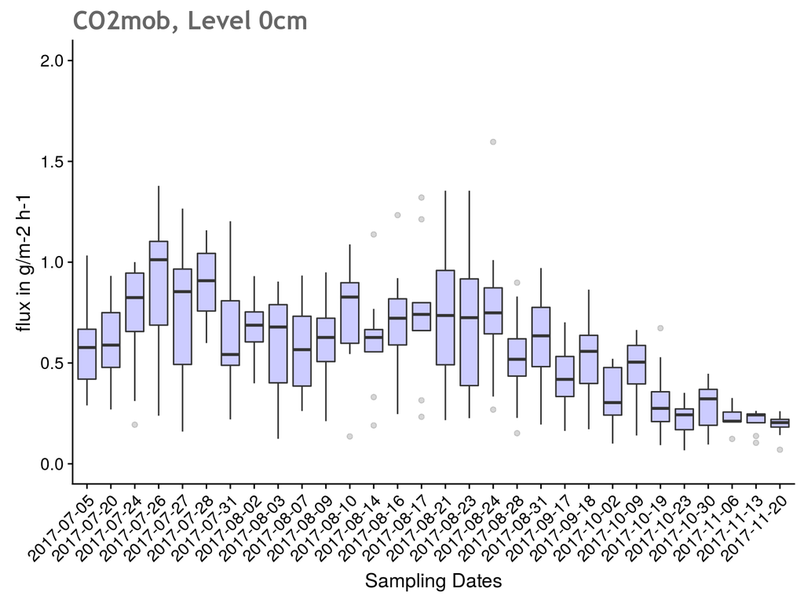

```r
co21
```

```r
  co22 <- ggplot(co280,
              aes(x=Sampled,
                  y=flux))
  co22 <- co22 +
        geom_boxplot(fill="blue", alpha=0.2) +
          ggtitle("CO2mob, Level 80cm") +
          labs(x="Sampling Dates", y="CO2 flux") +
          theme(plot.title = element_text(family = "Trebuchet MS", color="#666666", face="bold", size=18, hjust=0)) +
          theme(axis.text.x = element_text(angle = 45, hjust = 1)) +
          scale_y_continuous(name="flux in g/m-2 h-1", limits=c(0, 2))
```

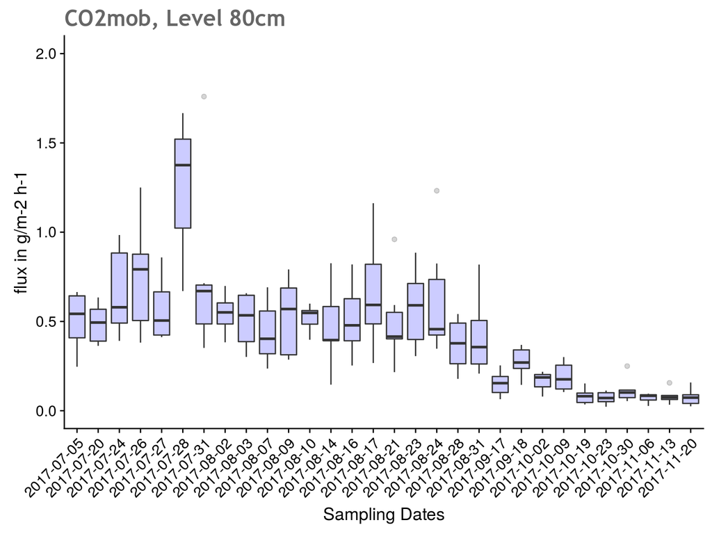

```r
  co22
```

```r
  co23 <- ggplot(co2170,
              aes(x=Sampled,
                  y=flux))
  co23 <- co23 +
        geom_boxplot(fill="blue", alpha=0.2) +
          ggtitle("CO2mob, Level 180cm") +
          labs(x="Sampling Dates", y="CO2 flux") +
          theme(plot.title = element_text(family = "Trebuchet MS", color="#666666", face="bold", size=18, hjust=0)) +
          theme(axis.text.x = element_text(angle = 45, hjust = 1)) +
          scale_y_continuous(name="flux in g/m-2 h-1", limits=c(0, 2))
```

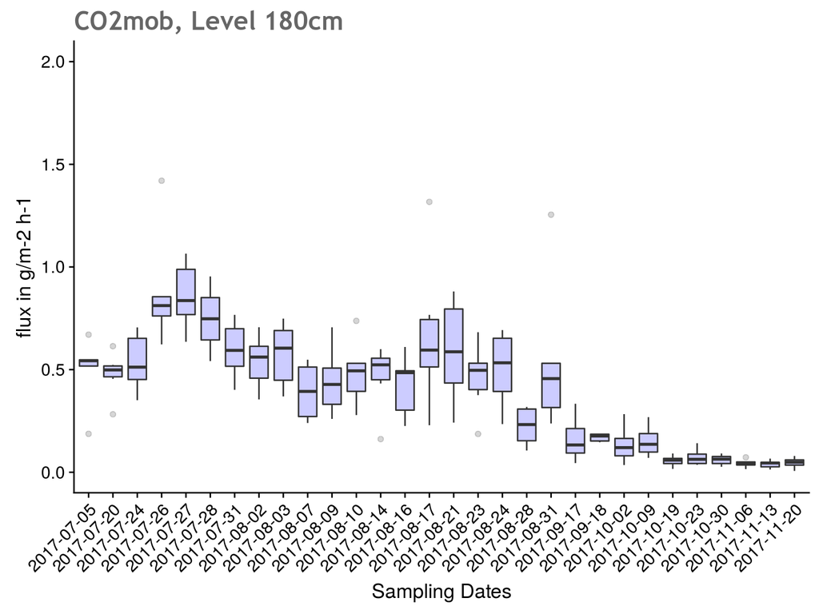

```r
  co23
```

# CO2 Boxplots from Control Site, no control spots, Level 0/80/170 cm

```r
  co2c1 <- ggplot(co20c,
              aes(x=Sampled,
                  y=flux))
  co2c1 <- co2c1 +
        geom_boxplot(fill="blue", alpha=0.2) +
          ggtitle("Control site: CO2mob, Level 0cm") +
          labs(x="Sampling Dates", y="CO2 flux") +
          theme(plot.title = element_text(family = "Trebuchet MS", color="#666666", face="bold", size=18, hjust=0)) +
          theme(axis.text.x = element_text(angle = 45, hjust = 1)) +
          scale_y_continuous(name="flux in g/m-2 h-1", limits=c(0, 2))
```

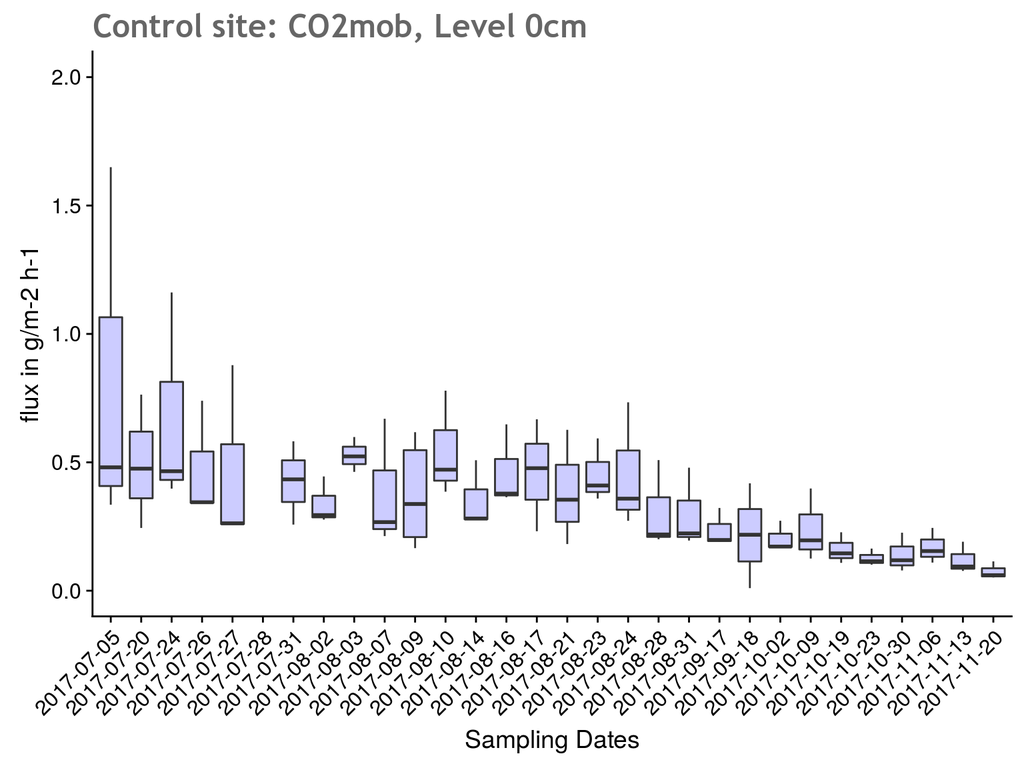

```r
  co2c1
```

```r
  co2c2 <- ggplot(co280c,
              aes(x=Sampled,
                  y=flux))
  co2c2 <- co2c2 +
        geom_boxplot(fill="blue", alpha=0.2) +
          ggtitle("Control site: CO2mob, Level 80cm") +
          labs(x="Sampling Dates", y="CO2 flux") +
          theme(plot.title = element_text(family = "Trebuchet MS", color="#666666", face="bold", size=18, hjust=0)) +
          theme(axis.text.x = element_text(angle = 45, hjust = 1)) +
          scale_y_continuous(name="flux in g/m-2 h-1", limits=c(0, 1))
```

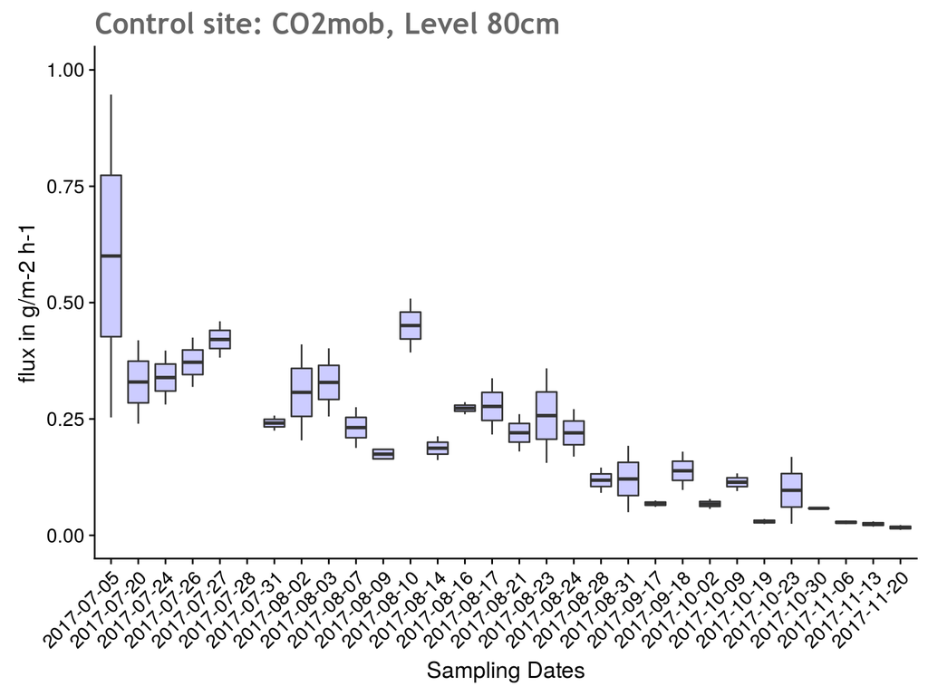

```r
co2c2
```

```r
  co2c3 <- ggplot(co2170c,
              aes(x=Sampled,
                  y=flux))
  co2c3 <- co2c3 +
        geom_boxplot(fill="blue", alpha=0.2) +
          ggtitle("Control site: CO2mob, Level 180cm") +
          labs(x="Sampling Dates", y="CO2 flux") +
          theme(plot.title = element_text(family = "Trebuchet MS", color="#666666", face="bold", size=18, hjust=0)) +
          theme(axis.text.x = element_text(angle = 45, hjust = 1)) +
          scale_y_continuous(name="flux in g/m-2 h-1", limits=c(0, 1))
```

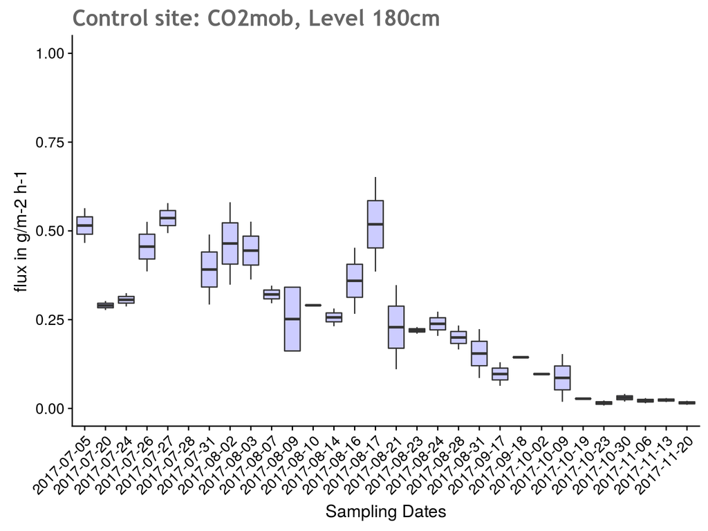

```r
  co2c3
```

# N2O AT NIGHT NOW !!!

```r
n2on <- read.csv("n2on.csv", header = TRUE)
```

```r
n2on
```

```
##      Sampled Tree1h0 Tree2h0 Tree3h0 Tree4h0 Tree5h0 Tree6h0 Tree7h0
## 1 2017-07-21   2.813  18.004   1.860   9.369   0.726   3.157   5.629
## 2 2017-07-28   0.889   4.830   0.328   6.060   0.731   0.476   3.766
## 3 2017-08-04   0.000   2.122   0.517   4.207   0.398   0.509   1.234
## 4 2017-08-11   5.997  76.318   6.192  11.791   0.421   7.472  17.629
## 5 2017-08-18  10.601 166.912  36.796 126.478   3.650  36.319  32.747
## 6 2017-08-25  62.633 495.920 355.729 198.240   8.946 153.181 139.886
## 7 2017-09-01   0.000  47.196   0.000  34.845  10.833  34.210   5.528
##   Tree8h0 Tree12h0 Tree2h80 Tree3h80 Tree4h80 Tree6h80 Tree8h80 Tree12h80
## 1   1.355    0.231    3.715    0.777    3.134    1.293    0.000     0.170
## 2   0.000    0.000    1.794    0.000    1.903    0.875    0.000     0.000
## 3   0.145    1.155    0.062    0.078    0.329    0.200    0.189     0.000
## 4   4.131    0.000    8.300    2.519    4.230    0.965    0.275     0.000
## 5   4.767    3.080   21.493   12.316   33.102    7.234    0.554     0.568
## 6  90.271  183.364  195.317   12.036   52.283   23.309    9.267     2.395
```

[output cut: 17 more lines]

### Re-Organising Data Colums, experimental sites

Zero level, experimental site

```r
  n2on0 <- gather(n2on, "olevel", "flux", Tree1h0:Tree12h0, factor_key=TRUE)
```

```r
n2on0
```

```
##       Sampled Tree2h80 Tree3h80 Tree4h80 Tree6h80 Tree8h80 Tree12h80
## 1  2017-07-21    3.715    0.777    3.134    1.293    0.000     0.170
## 2  2017-07-28    1.794    0.000    1.903    0.875    0.000     0.000
## 3  2017-08-04    0.062    0.078    0.329    0.200    0.189     0.000
## 4  2017-08-11    8.300    2.519    4.230    0.965    0.275     0.000
## 5  2017-08-18   21.493   12.316   33.102    7.234    0.554     0.568
## 6  2017-08-25  195.317   12.036   52.283   23.309    9.267     2.395
## 7  2017-09-01   27.657   29.531   17.697    5.197    0.000     2.416
## 8  2017-07-21    3.715    0.777    3.134    1.293    0.000     0.170
## 9  2017-07-28    1.794    0.000    1.903    0.875    0.000     0.000
## 10 2017-08-04    0.062    0.078    0.329    0.200    0.189     0.000
## 11 2017-08-11    8.300    2.519    4.230    0.965    0.275     0.000
## 12 2017-08-18   21.493   12.316   33.102    7.234    0.554     0.568
## 13 2017-08-25  195.317   12.036   52.283   23.309    9.267     2.395
## 14 2017-09-01   27.657   29.531   17.697    5.197    0.000     2.416
```

[output cut: 241 more lines]

80cm Level, experimental site

```r
  n2on80 <- gather(n2on, "80level", "flux", Tree2h80:Tree12h80, factor_key=TRUE)
```

```r
n2on80
```

```
##       Sampled Tree1h0 Tree2h0 Tree3h0 Tree4h0 Tree5h0 Tree6h0 Tree7h0
## 1  2017-07-21   2.813  18.004   1.860   9.369   0.726   3.157   5.629
## 2  2017-07-28   0.889   4.830   0.328   6.060   0.731   0.476   3.766
## 3  2017-08-04   0.000   2.122   0.517   4.207   0.398   0.509   1.234
## 4  2017-08-11   5.997  76.318   6.192  11.791   0.421   7.472  17.629
## 5  2017-08-18  10.601 166.912  36.796 126.478   3.650  36.319  32.747
## 6  2017-08-25  62.633 495.920 355.729 198.240   8.946 153.181 139.886
## 7  2017-09-01   0.000  47.196   0.000  34.845  10.833  34.210   5.528
## 8  2017-07-21   2.813  18.004   1.860   9.369   0.726   3.157   5.629
## 9  2017-07-28   0.889   4.830   0.328   6.060   0.731   0.476   3.766
## 10 2017-08-04   0.000   2.122   0.517   4.207   0.398   0.509   1.234
## 11 2017-08-11   5.997  76.318   6.192  11.791   0.421   7.472  17.629
## 12 2017-08-18  10.601 166.912  36.796 126.478   3.650  36.319  32.747
## 13 2017-08-25  62.633 495.920 355.729 198.240   8.946 153.181 139.886
## 14 2017-09-01   0.000  47.196   0.000  34.845  10.833  34.210   5.528
```

[output cut: 157 more lines]

170cm Level, experimental site

```r
  n2on170 <- gather(n2on, "170level", "flux", Tree2h170:Tree12h170, factor_key=TRUE)
```

```r
n2on170
```

```
##       Sampled Tree1h0 Tree2h0 Tree3h0 Tree4h0 Tree5h0 Tree6h0 Tree7h0
## 1  2017-07-21   2.813  18.004   1.860   9.369   0.726   3.157   5.629
## 2  2017-07-28   0.889   4.830   0.328   6.060   0.731   0.476   3.766
## 3  2017-08-04   0.000   2.122   0.517   4.207   0.398   0.509   1.234
## 4  2017-08-11   5.997  76.318   6.192  11.791   0.421   7.472  17.629
## 5  2017-08-18  10.601 166.912  36.796 126.478   3.650  36.319  32.747
## 6  2017-08-25  62.633 495.920 355.729 198.240   8.946 153.181 139.886
## 7  2017-09-01   0.000  47.196   0.000  34.845  10.833  34.210   5.528
## 8  2017-07-21   2.813  18.004   1.860   9.369   0.726   3.157   5.629
## 9  2017-07-28   0.889   4.830   0.328   6.060   0.731   0.476   3.766
## 10 2017-08-04   0.000   2.122   0.517   4.207   0.398   0.509   1.234
## 11 2017-08-11   5.997  76.318   6.192  11.791   0.421   7.472  17.629
## 12 2017-08-18  10.601 166.912  36.796 126.478   3.650  36.319  32.747
## 13 2017-08-25  62.633 495.920 355.729 198.240   8.946 153.181 139.886
## 14 2017-09-01   0.000  47.196   0.000  34.845  10.833  34.210   5.528
```

[output cut: 157 more lines]

# Re-Organising Data Colums, control sites

```r
  n2on0c <- gather(n2on, "olevelC", "flux", Tree9h0:Tree11h0, factor_key=TRUE)
```

```r
n2on0c
```

```
##       Sampled Tree1h0 Tree2h0 Tree3h0 Tree4h0 Tree5h0 Tree6h0 Tree7h0
## 1  2017-07-21   2.813  18.004   1.860   9.369   0.726   3.157   5.629
## 2  2017-07-28   0.889   4.830   0.328   6.060   0.731   0.476   3.766
## 3  2017-08-04   0.000   2.122   0.517   4.207   0.398   0.509   1.234
## 4  2017-08-11   5.997  76.318   6.192  11.791   0.421   7.472  17.629
## 5  2017-08-18  10.601 166.912  36.796 126.478   3.650  36.319  32.747
## 6  2017-08-25  62.633 495.920 355.729 198.240   8.946 153.181 139.886
## 7  2017-09-01   0.000  47.196   0.000  34.845  10.833  34.210   5.528
## 8  2017-07-21   2.813  18.004   1.860   9.369   0.726   3.157   5.629
## 9  2017-07-28   0.889   4.830   0.328   6.060   0.731   0.476   3.766
## 10 2017-08-04   0.000   2.122   0.517   4.207   0.398   0.509   1.234
## 11 2017-08-11   5.997  76.318   6.192  11.791   0.421   7.472  17.629
## 12 2017-08-18  10.601 166.912  36.796 126.478   3.650  36.319  32.747
## 13 2017-08-25  62.633 495.920 355.729 198.240   8.946 153.181 139.886
## 14 2017-09-01   0.000  47.196   0.000  34.845  10.833  34.210   5.528
```

[output cut: 73 more lines]

```r
  n2on80c <- gather(n2on, "80levelC", "flux", Tree9h80:Tree11h80, factor_key=TRUE)
```

```r
  n2on80c
```

```
##       Sampled Tree1h0 Tree2h0 Tree3h0 Tree4h0 Tree5h0 Tree6h0 Tree7h0
## 1  2017-07-21   2.813  18.004   1.860   9.369   0.726   3.157   5.629
## 2  2017-07-28   0.889   4.830   0.328   6.060   0.731   0.476   3.766
## 3  2017-08-04   0.000   2.122   0.517   4.207   0.398   0.509   1.234
## 4  2017-08-11   5.997  76.318   6.192  11.791   0.421   7.472  17.629
## 5  2017-08-18  10.601 166.912  36.796 126.478   3.650  36.319  32.747
## 6  2017-08-25  62.633 495.920 355.729 198.240   8.946 153.181 139.886
## 7  2017-09-01   0.000  47.196   0.000  34.845  10.833  34.210   5.528
## 8  2017-07-21   2.813  18.004   1.860   9.369   0.726   3.157   5.629
## 9  2017-07-28   0.889   4.830   0.328   6.060   0.731   0.476   3.766
## 10 2017-08-04   0.000   2.122   0.517   4.207   0.398   0.509   1.234
## 11 2017-08-11   5.997  76.318   6.192  11.791   0.421   7.472  17.629
## 12 2017-08-18  10.601 166.912  36.796 126.478   3.650  36.319  32.747
## 13 2017-08-25  62.633 495.920 355.729 198.240   8.946 153.181 139.886
## 14 2017-09-01   0.000  47.196   0.000  34.845  10.833  34.210   5.528
```

[output cut: 45 more lines]

```r
  n2on170c <- gather(n2on, "170levelC", "flux", Tree9h170:Tree11h170, factor_key=TRUE)
```

```r
n2on170c
```

```
##       Sampled Tree1h0 Tree2h0 Tree3h0 Tree4h0 Tree5h0 Tree6h0 Tree7h0
## 1  2017-07-21   2.813  18.004   1.860   9.369   0.726   3.157   5.629
## 2  2017-07-28   0.889   4.830   0.328   6.060   0.731   0.476   3.766
## 3  2017-08-04   0.000   2.122   0.517   4.207   0.398   0.509   1.234
## 4  2017-08-11   5.997  76.318   6.192  11.791   0.421   7.472  17.629
## 5  2017-08-18  10.601 166.912  36.796 126.478   3.650  36.319  32.747
## 6  2017-08-25  62.633 495.920 355.729 198.240   8.946 153.181 139.886
## 7  2017-09-01   0.000  47.196   0.000  34.845  10.833  34.210   5.528
## 8  2017-07-21   2.813  18.004   1.860   9.369   0.726   3.157   5.629
## 9  2017-07-28   0.889   4.830   0.328   6.060   0.731   0.476   3.766
## 10 2017-08-04   0.000   2.122   0.517   4.207   0.398   0.509   1.234
## 11 2017-08-11   5.997  76.318   6.192  11.791   0.421   7.472  17.629
## 12 2017-08-18  10.601 166.912  36.796 126.478   3.650  36.319  32.747
## 13 2017-08-25  62.633 495.920 355.729 198.240   8.946 153.181 139.886
## 14 2017-09-01   0.000  47.196   0.000  34.845  10.833  34.210   5.528
```

[output cut: 45 more lines]

# ! Data now look much better

# N2O Night Boxplots from Experimental Site, no control spots, Level 0/80/170 cm

```r
  n1 <- ggplot(n2on0,
              aes(x=Sampled,
                  y=flux))
  n1 <- n1 +
        geom_boxplot(fill="blue", alpha=0.2) +
          ggtitle("N2O Night, Level 0cm") +
          labs(x="Sampling Dates", y="N2O flux") +
          theme(plot.title = element_text(family = "Trebuchet MS", color="#666666", face="bold", size=18, hjust=0)) +
          theme(axis.text.x = element_text(angle = 45, hjust = 1)) +
          scale_y_continuous(name="flux in myg/m-2 h-1", limits=c(0, 20))
```

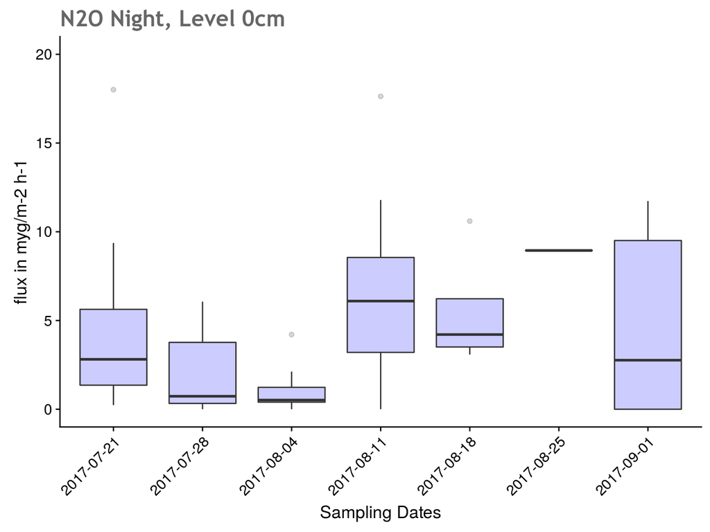

```r
  n1
```

```r
  n2 <- ggplot(n2on80,
              aes(x=Sampled,
                  y=flux))
  n2 <- n2 +
        geom_boxplot(fill="blue", alpha=0.2) +
          ggtitle("N2O Night, Level 80cm") +
          labs(x="Sampling Dates", y="N2O flux") +
          theme(plot.title = element_text(family = "Trebuchet MS", color="#666666", face="bold", size=18, hjust=0)) +
          theme(axis.text.x = element_text(angle = 45, hjust = 1)) +
          scale_y_continuous(name="flux in myg/m-2 h-1", limits=c(0, 20))
```

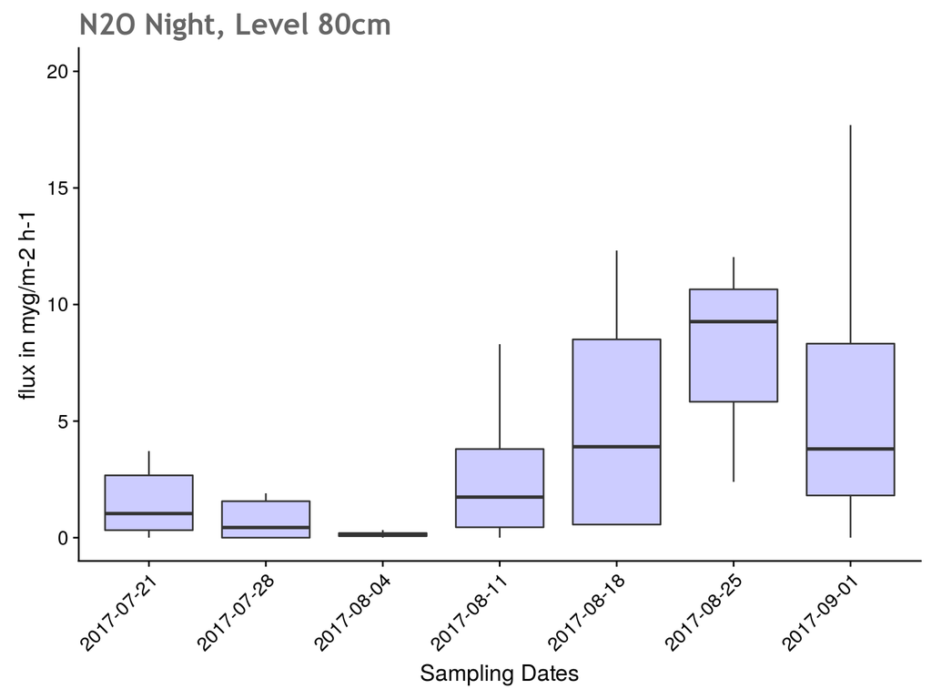

```r
  n2
```

```r
  n3 <- ggplot(n2on170,
              aes(x=Sampled,
                  y=flux))
  n3 <- n3 +
        geom_boxplot(fill="blue", alpha=0.2) +
          ggtitle("N2O night, Level 180cm") +
          labs(x="Sampling Dates", y="N2O flux") +
          theme(plot.title = element_text(family = "Trebuchet MS", color="#666666", face="bold", size=18, hjust=0)) +
          theme(axis.text.x = element_text(angle = 45, hjust = 1)) +
          scale_y_continuous(name="flux in myg/m-2 h-1", limits=c(0, 20))
```

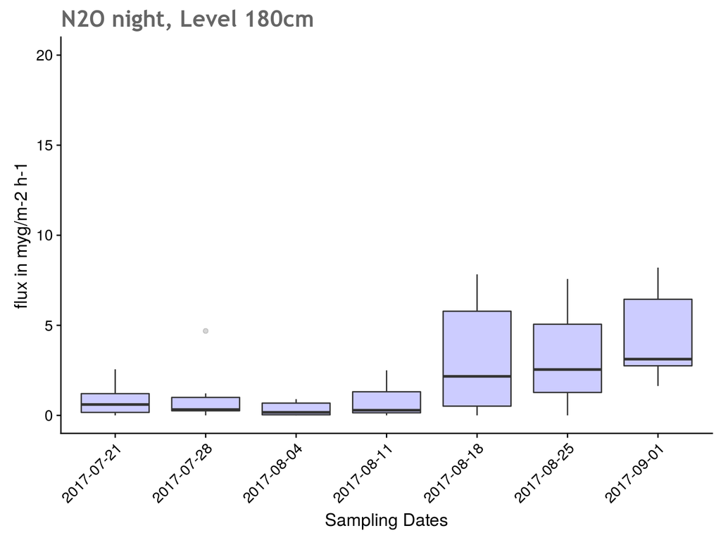

```r
  n3
```

# Multiplot Plot N2O NIGHT Fluxes from Experimental Sites somehow produces S***

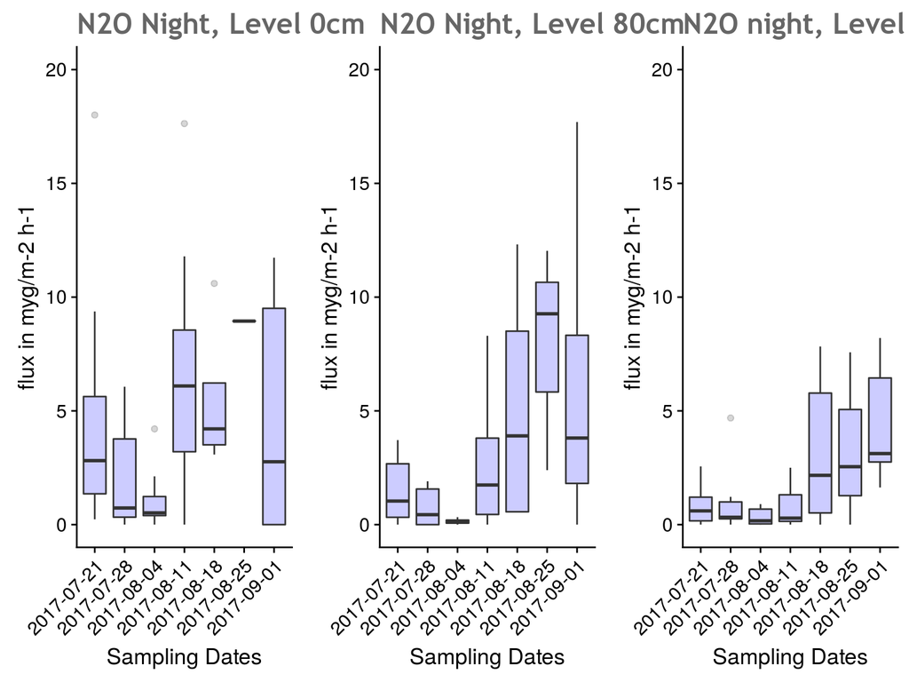

```r
    library(gridExtra)
    library(grid)
   grid.arrange(n1, n2, n3, ncol=3)
```

# N2O Boxplots NIGHT from Control Site, no control spots, Level 0/80/170 cm

```r
  nn1 <- ggplot(n2on0c,
              aes(x=Sampled,
                  y=flux))
  nn1 <- nn1 +
        geom_boxplot(fill="blue", alpha=0.2) +
          ggtitle("Control site: N2O Night, Level 0cm") +
          labs(x="Sampling Dates", y="N2O flux") +
          theme(plot.title = element_text(family = "Trebuchet MS", color="#666666", face="bold", size=18, hjust=0)) +
          theme(axis.text.x = element_text(angle = 45, hjust = 1)) +
          scale_y_continuous(name="flux in myg/m-2 h-1", limits=c(0, 20))
```

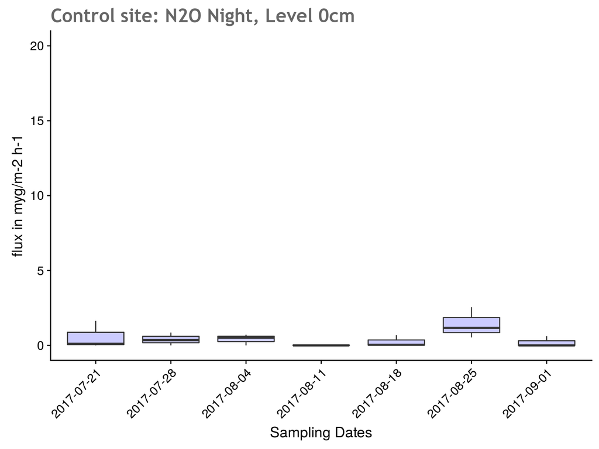

```r
  nn1
```

```r
  nn2 <- ggplot(n2on80c,
              aes(x=Sampled,
                  y=flux))
  nn2 <- nn2 +
        geom_boxplot(fill="blue", alpha=0.2) +
          ggtitle("Control site: N2O Night, Level 80cm") +
          labs(x="Sampling Dates", y="N2O flux") +
          theme(plot.title = element_text(family = "Trebuchet MS", color="#666666", face="bold", size=18, hjust=0)) +
          theme(axis.text.x = element_text(angle = 45, hjust = 1)) +
          scale_y_continuous(name="flux inmyg/m-2 h-1", limits=c(0, 20))
```

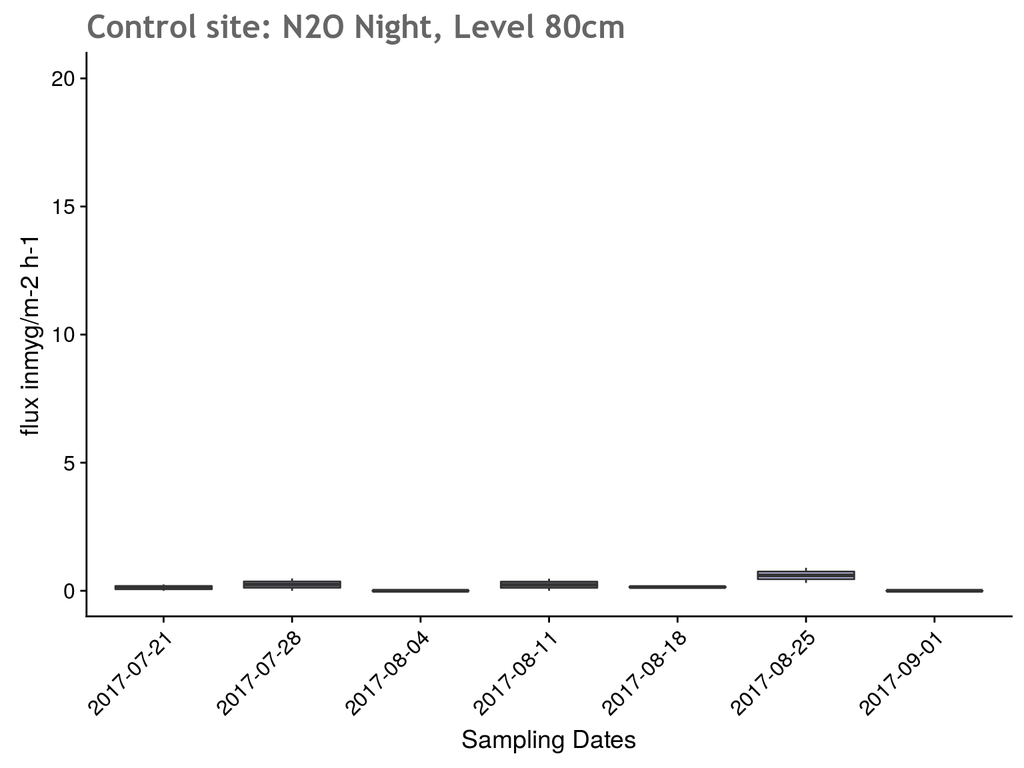

```r
  nn2
```

```r
  nn3 <- ggplot(n2on170c,
              aes(x=Sampled,
                  y=flux))
  nn3 <- nn3 +
        geom_boxplot(fill="blue", alpha=0.2) +
          ggtitle("Control site: N2O Night, Level 180cm") +
          labs(x="Sampling Dates", y="N2O flux") +
          theme(plot.title = element_text(family = "Trebuchet MS", color="#666666", face="bold", size=18, hjust=0)) +
          theme(axis.text.x = element_text(angle = 45, hjust = 1)) +
          scale_y_continuous(name="flux in myg/m-2 h-1", limits=c(0, 20))
```

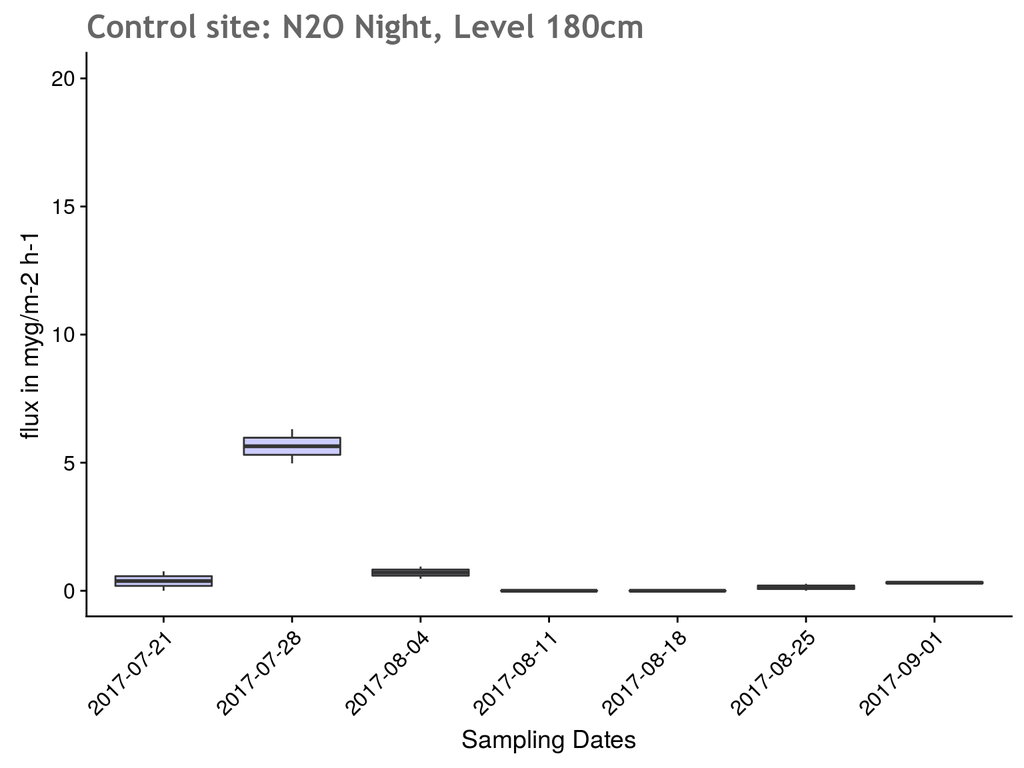

```r
  nn3
```